# Evaluation of p-curve simulation results

Author

Beth Clarke, Felix Schönbrodt, Angelika Stefan

Published

August 5, 2026

## Data wrangling and Goodness of Fit calculation

Combine simulation results from all conditions into one big dataset

```r
library(fitPCurve)
library(rio)
library(dplyr)
library(ggplot2)

# The working directory should be the project root
# if quarto:render is called
# if (!interactive()) {
#   print("Switching working directory to project root")
#   setwd("..")
# }


# reference p-curves
pcurves <- import("avg_pcurve_simulation_study/avg_pcurve.csv")

# load the multiple DV simulation results:
simres_realistic <- import("sim-results/sim_realistic.csv")
simres_realistic$condition <- "multDV_realistic"
simres_worst <- import("sim-results/sim_worst.csv")
simres_worst$condition <- "multDV_worst"
simres_perfect <- import("sim-results/sim_perfect.csv")
simres_perfect$condition <- "multDV_perfect"
simres_H0 <- import("sim-results/sim_H0.csv")
simres_H0$condition <- "multDV_H0"

# Delete unnecessary rows for different reporting strategies from simres_perfect      and simres_H0 (these yield identical results as there is only one p-value)
simres_perfect <- simres_perfect |> filter(strategy == 3)
simres_H0 <- simres_H0 |> filter(strategy == 3)

# load the optional stopping simulation results:
simres_optStop_worst <- import("sim-results/sim_optStop_worst.csv")
simres_optStop_worst$condition <- "optStop_worst"
simres_optStop_realistic <- import("sim-results/sim_optStop_realistic.csv")
simres_optStop_realistic$condition <- "optStop_realistic"

simres_multDV <- rbind(simres_realistic, simres_worst, simres_perfect, simres_H0)
simres_multDV$binsum <- rowSums(simres_multDV[, paste0("p", 1:5)])
stopifnot(all(simres_multDV$binsum |> round(6) == 1))
simres_multDV$type <- "multDV"

simres_optStop <- rbind(simres_optStop_realistic, simres_optStop_worst)
simres_optStop$binsum <- rowSums(simres_optStop[, paste0("p", 1:5)])
stopifnot(all(simres_optStop$binsum |> round(6) == 1))
simres_optStop$type <- "optStop"

# Combine simulations from both p-hacking strategies (they have different parameter columns)
simres <- bind_rows(simres_multDV, simres_optStop)

save(simres, file="sim-results/simres_all.RData")
save(simres, file="ShinyApp/simres_all.RData")
```

Compute G-squared fit statistics

```r
simres$fit_pcurve1_g2 <- g2(
  observed = simplify2array(pcurves[1, paste0("p", 1:5)]),
  expected = simres[, paste0("p", 1:5)], n = pcurves$nsig[1], tol=1e-6)

simres$fit_pcurve2_g2 <- g2(
  observed = simplify2array(pcurves[2, paste0("p", 1:5)]),
  expected = simres[, paste0("p", 1:5)], n = pcurves$nsig[2], tol=1e-6)
```

Also compute chi-squared and RMSE for robustness checks

```r
# Chi-squared
simres$fit_pcurve1_chi2 <- chi2(
  observed = simplify2array(pcurves[1, paste0("p", 1:5)]),
  expected = simres[, paste0("p", 1:5)], n = pcurves$nsig[1], tol=1e-6)
simres$fit_pcurve2_chi2 <- chi2(
  observed = simplify2array(pcurves[2, paste0("p", 1:5)]),
  expected = simres[, paste0("p", 1:5)], n = pcurves$nsig[2], tol=1e-6)

# RMSE
simres$fit_pcurve1_rmse <- rmse(
  observed = simplify2array(pcurves[1, paste0("p", 1:5)]),
  expected = simres[, paste0("p", 1:5)], n = pcurves$nsig[1])
simres$fit_pcurve2_rmse <- rmse(
  observed = simplify2array(pcurves[2, paste0("p", 1:5)]),
  expected = simres[, paste0("p", 1:5)], n = pcurves$nsig[2])
```

## Extract best fits in each “world”

### For the first p-curve:

Investigate best fits overall:

Find the best fit that is *not* in the realistic world:

```r
simres_ordered <- simres |> arrange(fit_pcurve1_g2)
which(!simres_ordered$condition %in% c("optStop_realistic", "multDV_realistic"))[1]
```

```
[1] 3227
```

Among the best fitting conditions, calculate percentage of both p-hacking strategies:

```r
simres |> arrange(fit_pcurve1_g2) |> slice(1:3226) |> select(condition) |> table()/3226 |> print()
```

```
[1] 3226
```

```
condition
 multDV_realistic optStop_realistic
        0.3803472         0.6196528
```

Total range of G-squared values:

```r
simres |> arrange(fit_pcurve1_g2) |> select(fit_pcurve1_g2) |> range() |> print()
```

```
[1]   0.709791 706.353871
```

G-squared quartiles:

```r
simres |> arrange(fit_pcurve1_g2) |> select(fit_pcurve1_g2) |> summary()  |> print()
```

```
 fit_pcurve1_g2
 Min.   :  0.7098
 1st Qu.: 10.6146
 Median : 24.3112
 Mean   : 39.6582
 3rd Qu.: 53.5779
 Max.   :706.3539
```

Look at parameters of best fitting condition:

```r
simres |> arrange(fit_pcurve1_g2) |> slice(1:10) |> print()
```

```
   nvar   r   d prop_Hacker prop_H1 het  iter alpha strategy        p1
1    NA  NA 0.4        0.10     0.1 0.4    NA    NA       NA 0.3391154
2     2 0.0 0.2        0.10     0.1 0.2 10000  0.05        3 0.3360215
3     2 0.0 0.2        0.10     0.1 0.2 10000  0.05        1 0.3373656
4     2 0.0 0.2        0.10     0.1 0.2 10000  0.05        2 0.3373656
5    NA  NA 0.4        0.10     0.2 0.4    NA    NA       NA 0.3642072
6    NA  NA 0.2        0.25     0.1 0.4    NA    NA       NA 0.3239550
7   150 0.9 0.3        0.10     0.2 0.0 10000  0.05        3 0.3524522
8    NA  NA 0.2        0.10     0.1 0.4    NA    NA       NA 0.3415354
9    10 0.9 0.6        0.75     0.1 0.2 10000  0.05        3 0.3344948
10   NA  NA 0.2        0.10     0.1 0.4    NA    NA       NA 0.3639309
          p2        p3        p4        p5 k_sig     k         condition binsum
1  0.1309627 0.1795317 0.1526453 0.1977450  1153 10000 optStop_realistic      1
2  0.1411290 0.1881720 0.1465054 0.1881720   744 10000  multDV_realistic      1
3  0.1411290 0.1881720 0.1478495 0.1854839   744 10000  multDV_realistic      1
```

[output cut: 29 more lines]

Extract best fits in each world using G-squared statistic

```r
# Flat world
simres |> filter(condition == "multDV_H0") |> arrange(fit_pcurve1_g2) |> print()
```

```
  nvar r d prop_Hacker prop_H1 het  iter alpha strategy        p1        p2
1    1 0 0           0       0   0 10000  0.05        1 0.2348337 0.1937378
2    1 0 0           0       0   0 10000  0.05        2 0.2348337 0.1937378
3    1 0 0           0       0   0 10000  0.05        3 0.2348337 0.1937378
         p3        p4        p5 k_sig     k condition binsum   type nmin nmax
1 0.1937378 0.1956947 0.1819961   511 10000 multDV_H0      1 multDV   NA   NA
2 0.1937378 0.1956947 0.1819961   511 10000 multDV_H0      1 multDV   NA   NA
3 0.1937378 0.1956947 0.1819961   511 10000 multDV_H0      1 multDV   NA   NA
  stepsize fit_pcurve1_g2 fit_pcurve2_g2 fit_pcurve1_chi2 fit_pcurve2_chi2
1       NA       13.16239       76.64917         13.35447         91.94151
2       NA       13.16239       76.64917         13.35447         91.94151
3       NA       13.16239       76.64917         13.35447         91.94151
  fit_pcurve1_rmse fit_pcurve2_rmse
1        0.0716647        0.1800079
2        0.0716647        0.1800079
3        0.0716647        0.1800079
```

```r
# Worst case, multiple DVs
simres |> filter(condition == "multDV_worst") |> arrange(fit_pcurve1_g2) |> slice(1:10) |> select(c(1:9, 10:15), fit_pcurve1_g2) |> round(2) |> print()
```

```
   nvar   r d prop_Hacker prop_H1 het  iter alpha strategy   p1   p2   p3   p4
1    30 0.6 0        0.25       0   0 10000  0.05        1 0.31 0.20 0.18 0.16
2    30 0.6 0        0.25       0   0 10000  0.05        2 0.31 0.20 0.18 0.16
3    10 0.0 0        0.10       0   0 10000  0.05        1 0.28 0.17 0.20 0.19
4    10 0.0 0        0.10       0   0 10000  0.05        2 0.28 0.17 0.20 0.19
5    30 0.6 0        1.00       0   0 10000  0.05        1 0.31 0.20 0.18 0.16
6    30 0.6 0        1.00       0   0 10000  0.05        2 0.31 0.20 0.18 0.16
7    70 0.9 0        0.50       0   0 10000  0.05        1 0.28 0.20 0.19 0.15
8    70 0.9 0        0.50       0   0 10000  0.05        2 0.28 0.20 0.19 0.15
9   150 0.9 0        1.00       0   0 10000  0.05        1 0.30 0.20 0.17 0.17
10  150 0.9 0        1.00       0   0 10000  0.05        2 0.30 0.20 0.17 0.17
     p5 k_sig fit_pcurve1_g2
1  0.15  1436           7.44
2  0.15  1436           7.44
3  0.16   842           7.92
4  0.16   842           7.92
5  0.15  4408           8.01
6  0.15  4408           8.01
7  0.17  1330           8.17
8  0.17  1330           8.17
9  0.15  2527           8.68
10 0.15  2527           8.68
```

```r
# Worst case, optional stopping
simres |> filter(condition == "optStop_worst") |> arrange(fit_pcurve1_g2) |> slice(1:10) |> select(c(3:8, 10:15, 20:23), fit_pcurve1_g2) |> round(2) |> print()
```

```
   d prop_Hacker prop_H1 het iter alpha   p1   p2   p3   p4   p5 k_sig nmin
1  0        0.10       0   0   NA    NA 0.20 0.19 0.21 0.20 0.20   578   22
2  0        0.10       0   0   NA    NA 0.21 0.21 0.19 0.20 0.19   563   50
3  0        0.50       0   0   NA    NA 0.21 0.21 0.17 0.20 0.21   866    8
4  0        0.10       0   0   NA    NA 0.20 0.22 0.20 0.18 0.20   553  177
5  0        0.25       0   0   NA    NA 0.20 0.22 0.20 0.18 0.20   644    8
6  0        0.75       0   0   NA    NA 0.20 0.19 0.21 0.22 0.19  1000   22
7  0        0.10       0   0   NA    NA 0.19 0.17 0.20 0.19 0.25   698   50
8  0        0.10       0   0   NA    NA 0.19 0.18 0.19 0.17 0.27   573   22
9  0        0.10       0   0   NA    NA 0.20 0.21 0.20 0.20 0.19   558    8
10 0        0.75       0   0   NA    NA 0.20 0.21 0.18 0.20 0.22  1042    8
   nmax stepsize fit_pcurve1_g2
1   177       50          17.85
2   177      100          18.05
3   177      100          18.92
4   444      100          19.62
5   177      100          20.07
6   177      100          20.27
7  1063      100          20.37
8    50        5          20.44
9   177      100          20.51
10  177      100          20.85
```

```r
# Realistic, multiple DVs
simres |> filter(condition == "multDV_realistic") |> arrange(fit_pcurve1_g2) |> slice(1:10) |> select(c(1:9, 10:15), fit_pcurve1_g2) |> round(2) |> print()
```

```
   nvar   r   d prop_Hacker prop_H1 het  iter alpha strategy   p1   p2   p3
1     2 0.0 0.2        0.10     0.1 0.2 10000  0.05        3 0.34 0.14 0.19
2     2 0.0 0.2        0.10     0.1 0.2 10000  0.05        1 0.34 0.14 0.19
3     2 0.0 0.2        0.10     0.1 0.2 10000  0.05        2 0.34 0.14 0.19
4   150 0.9 0.3        0.10     0.2 0.0 10000  0.05        3 0.35 0.13 0.16
5    10 0.9 0.6        0.75     0.1 0.2 10000  0.05        3 0.33 0.12 0.17
6    10 0.9 0.3        0.25     0.2 0.0 10000  0.05        3 0.35 0.14 0.18
7    70 0.9 0.4        0.10     0.1 0.0 10000  0.05        3 0.34 0.15 0.17
8   150 0.9 0.1        0.10     0.1 0.4 10000  0.05        3 0.33 0.13 0.17
9   150 0.6 0.4        0.10     0.2 0.2 10000  0.05        3 0.37 0.14 0.17
10   70 0.9 0.2        0.10     0.1 0.4 10000  0.05        3 0.33 0.15 0.17
     p4   p5 k_sig fit_pcurve1_g2
1  0.15 0.19   744           0.96
2  0.15 0.19   744           0.98
3  0.15 0.19   744           0.98
4  0.16 0.20  1203           1.23
5  0.16 0.21  1722           1.31
6  0.16 0.17  1265           1.41
7  0.15 0.19  1062           1.48
8  0.17 0.20   983           1.50
9  0.16 0.17  1852           1.51
10 0.15 0.19   981           1.54
```

```r
# Realistic, optional stopping
simres |> filter(condition == "optStop_realistic") |> arrange(fit_pcurve1_g2) |> slice(1:10) |> select(c(3:8, 10:15, 20:23), fit_pcurve1_g2) |> round(2) |> print()
```

```
     d prop_Hacker prop_H1 het iter alpha   p1   p2   p3   p4   p5 k_sig nmin
1  0.4        0.10     0.1 0.4   NA    NA 0.34 0.13 0.18 0.15 0.20  1153    8
2  0.4        0.10     0.2 0.4   NA    NA 0.36 0.13 0.16 0.14 0.21  1274    8
3  0.2        0.25     0.1 0.4   NA    NA 0.32 0.13 0.18 0.16 0.20  1244  177
4  0.2        0.10     0.1 0.4   NA    NA 0.34 0.13 0.18 0.17 0.19  1016   50
5  0.2        0.10     0.1 0.4   NA    NA 0.36 0.12 0.16 0.17 0.19   926  177
6  0.1        0.25     0.1 0.4   NA    NA 0.36 0.14 0.16 0.14 0.20  1069  444
7  0.2        0.10     0.2 0.2   NA    NA 0.37 0.14 0.17 0.14 0.17   968  177
8  0.4        0.50     0.1 0.2   NA    NA 0.37 0.12 0.16 0.17 0.19  1694  177
9  0.3        0.10     0.5 0.2   NA    NA 0.39 0.13 0.15 0.14 0.19  2044    8
10 0.7        0.25     0.1 0.4   NA    NA 0.38 0.12 0.15 0.16 0.19  1658    8
   nmax stepsize fit_pcurve1_g2
1   444       10           0.71
2    50        1           1.05
3  1063       50           1.19
4  1063       50           1.25
5   444       10           1.31
6  1063       50           1.33
7   444       50           1.33
8  1063      100           1.43
9   444        5           1.51
10 1063       50           1.57
```

```r
# Perfect
simres |> filter(condition == "multDV_perfect") |> arrange(fit_pcurve1_g2) |> slice(1:10) |> select(c(1:9, 10:15), fit_pcurve1_g2) |> round(2) |> print()
```

```
   nvar r   d prop_Hacker prop_H1 het  iter alpha strategy   p1   p2   p3   p4
1     1 0 0.1           0     0.7 0.0 10000  0.05        1 0.31 0.17 0.19 0.17
2     1 0 0.1           0     0.7 0.0 10000  0.05        2 0.31 0.17 0.19 0.17
3     1 0 0.1           0     0.7 0.0 10000  0.05        3 0.31 0.17 0.19 0.17
4     1 0 0.4           0     0.1 0.0 10000  0.05        1 0.37 0.16 0.15 0.16
5     1 0 0.4           0     0.1 0.0 10000  0.05        2 0.37 0.16 0.15 0.16
6     1 0 0.4           0     0.1 0.0 10000  0.05        3 0.37 0.16 0.15 0.16
7     1 0 0.3           0     0.1 0.4 10000  0.05        1 0.40 0.15 0.15 0.15
8     1 0 0.3           0     0.1 0.4 10000  0.05        2 0.40 0.15 0.15 0.15
9     1 0 0.3           0     0.1 0.4 10000  0.05        3 0.40 0.15 0.15 0.15
10    1 0 0.3           0     0.1 0.2 10000  0.05        1 0.38 0.16 0.17 0.15
     p5 k_sig fit_pcurve1_g2
1  0.16   780           4.36
2  0.16   780           4.36
3  0.16   780           4.36
4  0.16   852           4.45
5  0.16   852           4.45
6  0.16   852           4.45
7  0.14   840           4.63
8  0.14   840           4.63
9  0.14   840           4.63
10 0.14   719           4.76
```

Robustness checks: Check if results change depending on the Goodness of fit statistic

Worst case, multiple DVs

```r
simres$sim_ID <- rownames(simres)

# Worst case, multiple DVs
G2_fits <- simres |> filter(condition == "multDV_worst") |> arrange(fit_pcurve1_g2) |> slice(1:5) |> select("sim_ID", "fit_pcurve1_g2")
Chi2_fits <- simres |> filter(condition == "multDV_worst") |> arrange(fit_pcurve1_chi2) |> slice(1:5) |> select("sim_ID", "fit_pcurve1_chi2")
RMSE_fits <- simres |> filter(condition == "multDV_worst") |> arrange(fit_pcurve1_rmse) |> slice(1:5) |> select("sim_ID", "fit_pcurve1_rmse")

worstcase_multDV_fits <- cbind(G2_fits, Chi2_fits, RMSE_fits)
colnames(worstcase_multDV_fits) <- c("G2_best_sims", "G2", "Chi2_best_sims", "Chi2", "RMSE_best_sims", "RMSE")

worstcase_multDV_fits
```

```
  G2_best_sims       G2 Chi2_best_sims     Chi2 RMSE_best_sims       RMSE
1        43318 7.443096          43318 6.815680          43318 0.04980674
2        43319 7.443096          43319 6.815680          43319 0.04980674
3        43207 7.919724          43534 7.387641          43534 0.05091400
4        43208 7.919724          43535 7.387641          43535 0.05091400
5        43534 8.006183          43411 7.519065          43252 0.05337428
```

Worst case, optional stopping

```r
# Worst case, optional stopping
G2_fits <- simres |> filter(condition == "optStop_worst") |> arrange(fit_pcurve1_g2) |> slice(1:5) |> select("sim_ID", "fit_pcurve1_g2")
Chi2_fits <- simres |> filter(condition == "optStop_worst") |> arrange(fit_pcurve1_chi2) |> slice(1:5) |> select("sim_ID", "fit_pcurve1_chi2")
RMSE_fits <- simres |> filter(condition == "optStop_worst") |> arrange(fit_pcurve1_rmse) |> slice(1:5) |> select("sim_ID", "fit_pcurve1_rmse")

worstcase_optstop_fits <- cbind(G2_fits, Chi2_fits, RMSE_fits)
colnames(worstcase_optstop_fits) <- c("G2_best_sims", "G2", "Chi2_best_sims", "Chi2", "RMSE_best_sims", "RMSE")

worstcase_optstop_fits
```

```
  G2_best_sims       G2 Chi2_best_sims     Chi2 RMSE_best_sims       RMSE
1        85554 17.85434          85619 19.06570          85554 0.08337491
2        85619 18.05175          85554 19.64736          85619 0.08368832
3        85611 18.92024          85611 19.81550          85611 0.08546927
4        85639 19.61706          85639 20.90227          85639 0.08727051
5        85610 20.07119          85610 21.48380          85610 0.08825362
```

Realistic, multiple DVs

```r
# Realistic, multiple DVs
G2_fits <- simres |> filter(condition == "multDV_realistic") |> arrange(fit_pcurve1_g2) |> slice(1:5) |> select("sim_ID", "fit_pcurve1_g2")
Chi2_fits <- simres |> filter(condition == "multDV_realistic") |> arrange(fit_pcurve1_chi2) |> slice(1:5) |> select("sim_ID", "fit_pcurve1_chi2")
RMSE_fits <- simres |> filter(condition == "multDV_realistic") |> arrange(fit_pcurve1_rmse) |> slice(1:5) |> select("sim_ID", "fit_pcurve1_rmse")

multDV_realistic_fits <- cbind(G2_fits, Chi2_fits, RMSE_fits)
colnames(multDV_realistic_fits) <- c("G2_best_sims", "G2", "Chi2_best_sims", "Chi2", "RMSE_best_sims", "RMSE")

multDV_realistic_fits
```

```
  G2_best_sims        G2 Chi2_best_sims      Chi2 RMSE_best_sims       RMSE
1        14475 0.9550184          14475 0.9133779          14475 0.01734977
2        14473 0.9761291          14473 0.9337193          14473 0.01735118
3        14474 0.9761291          14474 0.9337193          14474 0.01735118
4         3096 1.2271923           3096 1.2424745           3096 0.01876967
5        16551 1.3096043          16551 1.3092200           3663 0.01970638
```

Realistic, optional stopping

```r
# Realistic, optional stopping
G2_fits <- simres |> filter(condition == "optStop_realistic") |> arrange(fit_pcurve1_g2) |> slice(1:5) |> select("sim_ID", "fit_pcurve1_g2")
Chi2_fits <- simres |> filter(condition == "optStop_realistic") |> arrange(fit_pcurve1_chi2) |> slice(1:5) |> select("sim_ID", "fit_pcurve1_chi2")
RMSE_fits <- simres |> filter(condition == "optStop_realistic") |> arrange(fit_pcurve1_rmse) |> slice(1:5) |> select("sim_ID", "fit_pcurve1_rmse")

optstop_realistic_fits <- cbind(G2_fits, Chi2_fits, RMSE_fits)
colnames(optstop_realistic_fits) <- c("G2_best_sims", "G2", "Chi2_best_sims", "Chi2", "RMSE_best_sims", "RMSE")

optstop_realistic_fits
```

```
  G2_best_sims       G2 Chi2_best_sims      Chi2 RMSE_best_sims       RMSE
1        77599 0.709791          77599 0.6978706          77599 0.01530686
2        76729 1.052736          76729 1.0901104          76729 0.01741977
3        74625 1.185874          74625 1.1703978          72925 0.01903095
4        74599 1.253751          74599 1.2112422          60729 0.01945253
5        74224 1.314382          60729 1.3012777          74224 0.01952554
```

Perfect

```r
# Perfect
G2_fits <- simres |> filter(condition == "multDV_perfect") |> arrange(fit_pcurve1_g2) |> slice(1:5) |> select("sim_ID", "fit_pcurve1_g2")
Chi2_fits <- simres |> filter(condition == "multDV_perfect") |> arrange(fit_pcurve1_chi2) |> slice(1:5) |> select("sim_ID", "fit_pcurve1_chi2")
RMSE_fits <- simres |> filter(condition == "multDV_perfect") |> arrange(fit_pcurve1_rmse) |> slice(1:5) |> select("sim_ID", "fit_pcurve1_rmse")

perfect_fits <- cbind(G2_fits, Chi2_fits, RMSE_fits)
colnames(perfect_fits) <- c("G2_best_sims", "G2", "Chi2_best_sims", "Chi2", "RMSE_best_sims", "RMSE")

perfect_fits
```

```
  G2_best_sims       G2 Chi2_best_sims     Chi2 RMSE_best_sims       RMSE
1        43657 4.356223          43657 4.151854          43570 0.03528033
2        43658 4.356223          43658 4.151854          43571 0.03528033
3        43659 4.356223          43659 4.151854          43572 0.03528033
4        43570 4.446438          43570 4.413531          43687 0.03645939
5        43571 4.446438          43571 4.413531          43688 0.03645939
```

Flat

```r
# Flat
G2_fits <- simres |> filter(condition == "multDV_H0") |> arrange(fit_pcurve1_g2) |> slice(1:5) |> select("sim_ID", "fit_pcurve1_g2")
Chi2_fits <- simres |> filter(condition == "multDV_H0") |> arrange(fit_pcurve1_chi2) |> slice(1:5) |> select("sim_ID", "fit_pcurve1_chi2")
RMSE_fits <- simres |> filter(condition == "multDV_H0") |> arrange(fit_pcurve1_rmse) |> slice(1:5) |> select("sim_ID", "fit_pcurve1_rmse")

flat_fits <- cbind(G2_fits, Chi2_fits, RMSE_fits)
colnames(perfect_fits) <- c("G2_best_sims", "G2", "Chi2_best_sims", "Chi2", "RMSE_best_sims", "RMSE")

flat_fits
```

```
  sim_ID fit_pcurve1_g2 sim_ID fit_pcurve1_chi2 sim_ID fit_pcurve1_rmse
1  43921       13.16239  43921         13.35447  43921        0.0716647
2  43922       13.16239  43922         13.35447  43922        0.0716647
3  43923       13.16239  43923         13.35447  43923        0.0716647
```

G2 and RMSE differ, so we investigate the parameters:

```r
print(simres[simres$sim_ID == perfect_fits$G2_best_sims[1], ])
```

```
      nvar r   d prop_Hacker prop_H1 het  iter alpha strategy        p1
43657    1 0 0.1           0     0.7   0 10000  0.05        1 0.3102564
             p2        p3        p4        p5 k_sig     k      condition binsum
43657 0.1653846 0.1884615 0.1717949 0.1641026   780 10000 multDV_perfect      1
        type nmin nmax stepsize fit_pcurve1_g2 fit_pcurve2_g2 fit_pcurve1_chi2
43657 multDV   NA   NA       NA       4.356223       46.08613         4.151854
      fit_pcurve2_chi2 fit_pcurve1_rmse fit_pcurve2_rmse sim_ID
43657         49.33195       0.03818075        0.1432857  43657
```

```r
print(simres[simres$sim_ID == perfect_fits$RMSE_best_sims[1], ])
```

```
      nvar r   d prop_Hacker prop_H1 het  iter alpha strategy        p1
43570    1 0 0.4           0     0.1   0 10000  0.05        1 0.3720657
             p2        p3       p4       p5 k_sig     k      condition binsum
43570 0.1631455 0.1502347 0.157277 0.157277   852 10000 multDV_perfect      1
        type nmin nmax stepsize fit_pcurve1_g2 fit_pcurve2_g2 fit_pcurve1_chi2
43570 multDV   NA   NA       NA       4.446438       27.86257         4.413531
      fit_pcurve2_chi2 fit_pcurve1_rmse fit_pcurve2_rmse sim_ID
43570         28.13132       0.03528033        0.1121401  43570
```

Find out how the condition picked by RMSE fared under G2:

```r
allG2_fits <- simres |> filter(condition == "multDV_perfect") |> arrange(fit_pcurve1_g2) |> select("sim_ID")
which(allG2_fits == perfect_fits$RMSE_best_sims[1])
```

```
[1] 4
```

Compute BICs for between-world comparisons (accounting for model complexity)

```r
# Number of free parameters in each simulated "world"
simres$free_parameters <- case_match(simres$condition,
                                     "multDV_realistic" ~ 7,
                                     "multDV_worst" ~ 4,
                                     "multDV_perfect" ~ 3,
                                     "multDV_H0" ~ 0,
                                     "optStop_realistic" ~ 7,
                                     "optStop_worst" ~ 4)
# Compute BIC from G-squared and number of free parameters
simres$BIC <- simres$fit_pcurve1_g2 + simres$free_parameters * log(pcurves$nsig[1])

# Compare BICs for best fits
simres |> group_by(condition) |> arrange(fit_pcurve1_g2) |> slice(1) |> select(BIC, fit_pcurve1_g2) |> ungroup() |> print()
```

```
# A tibble: 6 × 3
  condition           BIC fit_pcurve1_g2
  <chr>             <dbl>          <dbl>
1 multDV_H0          13.2         13.2
2 multDV_perfect     18.5          4.36
3 multDV_realistic   34.0          0.955
4 multDV_worst       26.4          7.44
5 optStop_realistic  33.8          0.710
6 optStop_worst      36.8         17.9
```

Visualisation

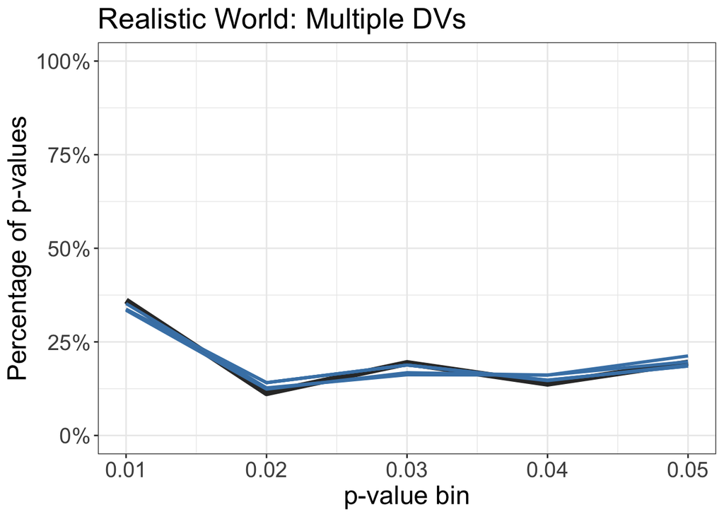

```r
plot_pcurves(simres |> filter(condition == "multDV_realistic"), poriginal = simplify2array(pcurves[1, paste0("p", 1:5)]), n_best = 5, GOF="g2", n_studies = pcurves$nsig[1], tol = 1e-6, title = "Realistic World: Multiple DVs")
```

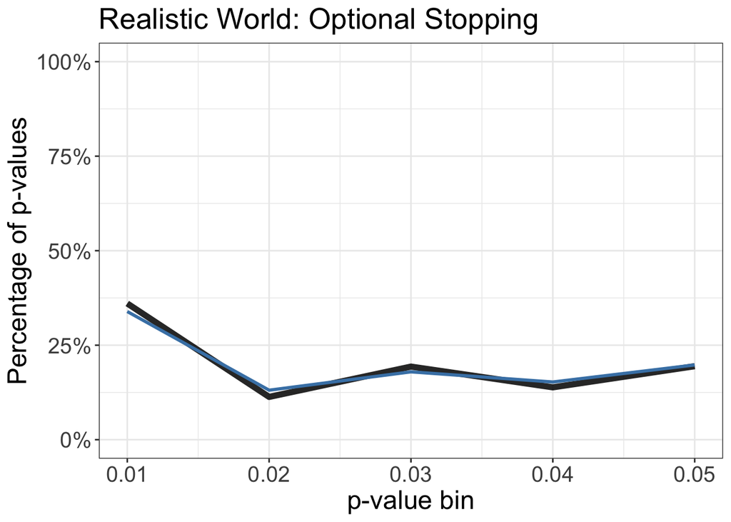

```r
plot_pcurves(simres |> filter(condition == "optStop_realistic"), poriginal = simplify2array(pcurves[1, paste0("p", 1:5)]), n_best = 1, GOF="g2", n_studies = pcurves$nsig[1], tol = 1e-6, title = "Realistic World: Optional Stopping")
```

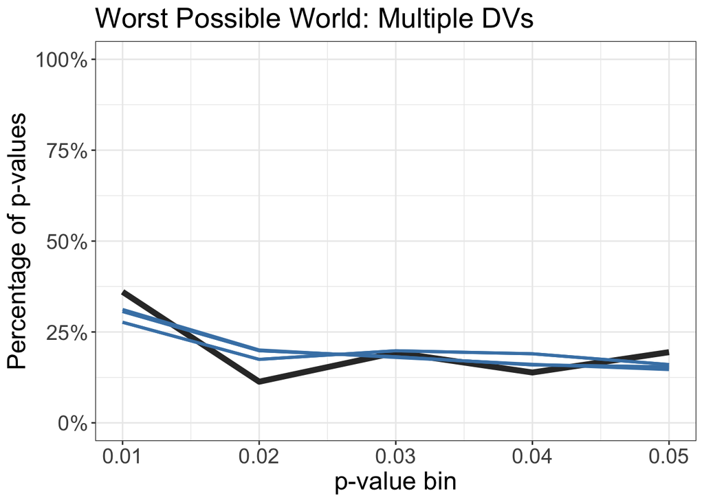

```r
plot_pcurves(simres |> filter(condition == "multDV_worst"), poriginal = simplify2array(pcurves[1, paste0("p", 1:5)]), n_best = 5, GOF="g2", n_studies = pcurves$nsig[1], tol = 1e-6, title = "Worst Possible World: Multiple DVs")
```

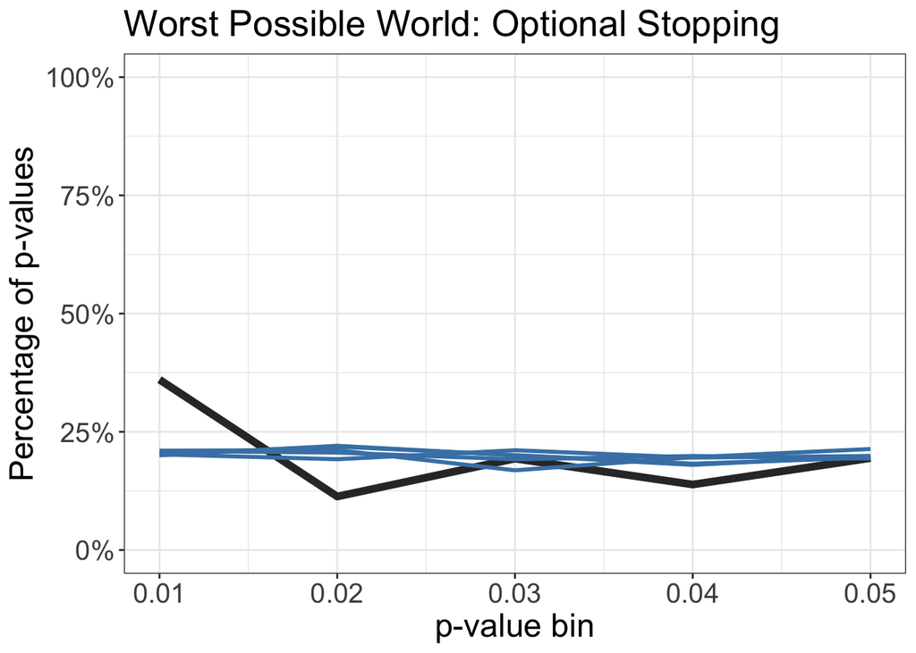

```r
plot_pcurves(simres |> filter(condition == "optStop_worst"), poriginal = simplify2array(pcurves[1, paste0("p", 1:5)]), n_best = 5, GOF="g2", n_studies = pcurves$nsig[1], tol = 1e-6, title = "Worst Possible World: Optional Stopping")
```

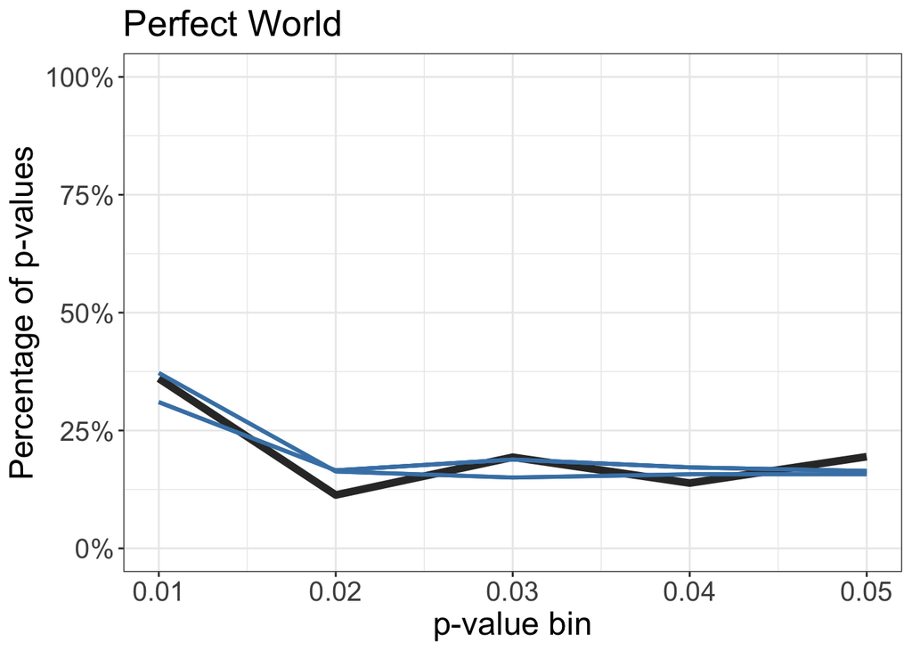

```r
plot_pcurves(simres |> filter(condition == "multDV_perfect"), poriginal = simplify2array(pcurves[1, paste0("p", 1:5)]), n_best = 5, GOF="g2", n_studies = pcurves$nsig[1], tol = 1e-6, title = "Perfect World")
```

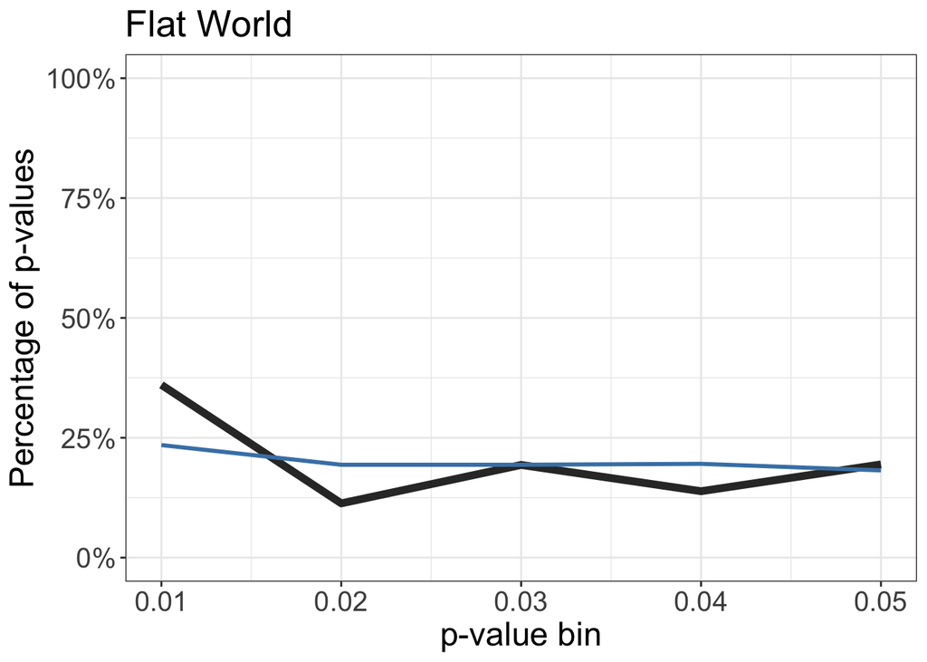

```r
plot_pcurves(simres |> filter(condition == "multDV_H0"), poriginal = simplify2array(pcurves[1, paste0("p", 1:5)]), n_best = 1, GOF="g2", n_studies = pcurves$nsig[1], tol = 1e-6, title = "Flat World")
```

### For the second p-curve:

Investigate best fits overall:

Find the best fit that is *not* in the realistic world:

```r
simres_ordered <- simres |> arrange(fit_pcurve2_g2)
which(!simres_ordered$condition %in% c("optStop_realistic", "multDV_realistic"))[1]
```

```
[1] 32
```

G-squared quartiles:

```r
simres |> arrange(fit_pcurve2_g2) |> select(fit_pcurve2_g2) |> summary()  |> print()
```

```
 fit_pcurve2_g2
 Min.   :  0.01481
 1st Qu.:  5.35104
 Median : 18.59942
 Mean   : 46.54806
 3rd Qu.: 58.02826
 Max.   :591.77746
```

Extract best fits in each world using G-squared statistic

```r
# Flat world
simres |> filter(condition == "multDV_H0") |> arrange(fit_pcurve2_g2) |> print()
```

```
  nvar r d prop_Hacker prop_H1 het  iter alpha strategy        p1        p2
1    1 0 0           0       0   0 10000  0.05        1 0.2348337 0.1937378
2    1 0 0           0       0   0 10000  0.05        2 0.2348337 0.1937378
3    1 0 0           0       0   0 10000  0.05        3 0.2348337 0.1937378
         p3        p4        p5 k_sig     k condition binsum   type nmin nmax
1 0.1937378 0.1956947 0.1819961   511 10000 multDV_H0      1 multDV   NA   NA
2 0.1937378 0.1956947 0.1819961   511 10000 multDV_H0      1 multDV   NA   NA
3 0.1937378 0.1956947 0.1819961   511 10000 multDV_H0      1 multDV   NA   NA
  stepsize fit_pcurve1_g2 fit_pcurve2_g2 fit_pcurve1_chi2 fit_pcurve2_chi2
1       NA       13.16239       76.64917         13.35447         91.94151
2       NA       13.16239       76.64917         13.35447         91.94151
3       NA       13.16239       76.64917         13.35447         91.94151
  fit_pcurve1_rmse fit_pcurve2_rmse sim_ID free_parameters      BIC
1        0.0716647        0.1800079  43921               0 13.16239
2        0.0716647        0.1800079  43922               0 13.16239
3        0.0716647        0.1800079  43923               0 13.16239
```

```r
# Worst case, multiple DVs
simres |> filter(condition == "multDV_worst") |> arrange(fit_pcurve2_g2) |> slice(1:5) |> select(c(1:9, 10:15), fit_pcurve2_g2) |> round(2) |> print()
```

```
  nvar   r d prop_Hacker prop_H1 het  iter alpha strategy   p1   p2   p3   p4
1  150 0.0 0        0.10       0   0 10000  0.05        1 0.60 0.18 0.09 0.08
2  150 0.0 0        0.10       0   0 10000  0.05        2 0.60 0.18 0.09 0.08
3  150 0.3 0        0.25       0   0 10000  0.05        1 0.53 0.22 0.13 0.07
4  150 0.3 0        0.25       0   0 10000  0.05        2 0.53 0.22 0.13 0.07
5  150 0.3 0        0.10       0   0 10000  0.05        1 0.46 0.21 0.14 0.11
    p5 k_sig fit_pcurve2_g2
1 0.05  1458           2.67
2 0.05  1458           2.67
3 0.05  2863           7.59
4 0.05  2863           7.59
5 0.08  1457          10.02
```

```r
# Worst case, optional stopping
simres |> filter(condition == "optStop_worst") |> arrange(fit_pcurve2_g2) |> slice(1:5) |> select(c(3:8, 10:15, 20:23), fit_pcurve2_g2) |> round(2) |> print()
```

```
  d prop_Hacker prop_H1 het iter alpha   p1   p2   p3   p4   p5 k_sig nmin nmax
1 0        0.10       0   0   NA    NA 0.21 0.21 0.19 0.20 0.19   563   50  177
2 0        0.50       0   0   NA    NA 0.21 0.21 0.17 0.20 0.21   866    8  177
3 0        0.10       0   0   NA    NA 0.20 0.22 0.20 0.18 0.20   553  177  444
4 0        0.10       0   0   NA    NA 0.20 0.19 0.21 0.20 0.20   578   22  177
5 0        0.25       0   0   NA    NA 0.20 0.22 0.20 0.18 0.20   644    8  177
  stepsize fit_pcurve1_g2 fit_pcurve2_g2
1      100          18.05          90.30
2      100          18.92          90.77
3      100          19.62          94.10
4       50          17.85          95.54
5      100          20.07          95.55
```

```r
# Realistic, multiple DVs
simres |> filter(condition == "multDV_realistic") |> arrange(fit_pcurve2_g2) |> slice(1:5) |> select(c(1:9, 10:14), fit_pcurve2_g2) |> round(2) |> print()
```

```
  nvar   r   d prop_Hacker prop_H1 het  iter alpha strategy   p1   p2  p3  p4
1   70 0.9 0.3        1.00     0.5 0.4 10000  0.05        1 0.60 0.14 0.1 0.1
2   70 0.9 0.3        1.00     0.5 0.4 10000  0.05        2 0.60 0.14 0.1 0.1
3   70 0.3 0.6        0.10     0.2 0.4 10000  0.05        1 0.59 0.14 0.1 0.1
4   70 0.3 0.6        0.10     0.2 0.4 10000  0.05        2 0.59 0.14 0.1 0.1
5    2 0.3 0.5        0.75     0.5 0.2 10000  0.05        3 0.59 0.14 0.1 0.1
    p5 fit_pcurve2_g2
1 0.07           0.01
2 0.07           0.01
3 0.07           0.02
4 0.07           0.02
5 0.08           0.03
```

```r
# Realistic, optional stopping
simres |> filter(condition == "optStop_realistic") |> arrange(fit_pcurve2_g2) |> slice(1:5) |> select(c(3:8, 10:15, 20:23), fit_pcurve2_g2) |> round(2) |> print()
```

```
    d prop_Hacker prop_H1 het iter alpha   p1   p2  p3   p4   p5 k_sig nmin
1 0.4         0.1     0.7 0.0   NA    NA 0.59 0.14 0.1 0.09 0.07  3394   50
2 0.6         0.1     0.3 0.0   NA    NA 0.60 0.14 0.1 0.09 0.07  2288    8
3 0.3         0.1     0.7 0.4   NA    NA 0.60 0.13 0.1 0.09 0.07  3229   22
4 0.6         0.1     0.3 0.2   NA    NA 0.59 0.14 0.1 0.09 0.08  2181   50
5 0.3         1.0     0.7 0.4   NA    NA 0.59 0.14 0.1 0.09 0.07  5445   22
  nmax stepsize fit_pcurve1_g2 fit_pcurve2_g2
1 1063      100          37.42           0.02
2  177       50          39.37           0.04
3 1063       50          37.43           0.05
4  177       10          36.65           0.05
5  177      100          36.50           0.06
```

```r
# Perfect
simres |> filter(condition == "multDV_perfect") |> arrange(fit_pcurve2_g2) |> slice(1:5) |> select(c(1:9, 10:15), fit_pcurve2_g2) |> round(2) |> print()
```

```
  nvar r   d prop_Hacker prop_H1 het  iter alpha strategy  p1   p2  p3   p4
1    1 0 0.5           0     0.3 0.0 10000  0.05        1 0.6 0.14 0.1 0.09
2    1 0 0.5           0     0.3 0.0 10000  0.05        2 0.6 0.14 0.1 0.09
3    1 0 0.5           0     0.3 0.0 10000  0.05        3 0.6 0.14 0.1 0.09
4    1 0 0.5           0     0.3 0.2 10000  0.05        1 0.6 0.13 0.1 0.09
5    1 0 0.5           0     0.3 0.2 10000  0.05        2 0.6 0.13 0.1 0.09
    p5 k_sig fit_pcurve2_g2
1 0.08  1841           0.07
2 0.08  1841           0.07
3 0.08  1841           0.07
4 0.07  1829           0.12
5 0.07  1829           0.12
```

Robustness checks: Check if results change depending on the Goodness of fit statistic

```r
simres$sim_ID <- rownames(simres)

# Worst case, multiple DVs
G2_fits <- simres |> filter(condition == "multDV_worst") |> arrange(fit_pcurve2_g2) |> slice(1:5) |> select("sim_ID", "fit_pcurve2_g2")
Chi2_fits <- simres |> filter(condition == "multDV_worst") |> arrange(fit_pcurve2_chi2) |> slice(1:5) |> select("sim_ID", "fit_pcurve2_chi2")
RMSE_fits <- simres |> filter(condition == "multDV_worst") |> arrange(fit_pcurve2_rmse) |> slice(1:5) |> select("sim_ID", "fit_pcurve2_rmse")

worstcase_multDV_fits <- cbind(G2_fits, Chi2_fits, RMSE_fits)
colnames(worstcase_multDV_fits) <- c("G2_best_sims", "G2", "Chi2_best_sims", "Chi2", "RMSE_best_sims", "RMSE")

worstcase_multDV_fits
```

```
  G2_best_sims        G2 Chi2_best_sims     Chi2 RMSE_best_sims       RMSE
1        43216  2.669846          43216 2.678413          43216 0.02250612
2        43217  2.669846          43217 2.678413          43217 0.02250612
3        43306  7.593324          43306 7.228362          43450 0.04827650
4        43307  7.593324          43307 7.228362          43451 0.04827650
5        43234 10.019187          43234 9.836735          43306 0.04863596
```

```r
# Worst case, optional stopping
G2_fits <- simres |> filter(condition == "optStop_worst") |> arrange(fit_pcurve2_g2) |> slice(1:5) |> select("sim_ID", "fit_pcurve2_g2")
Chi2_fits <- simres |> filter(condition == "optStop_worst") |> arrange(fit_pcurve2_chi2) |> slice(1:5) |> select("sim_ID", "fit_pcurve2_chi2")
RMSE_fits <- simres |> filter(condition == "optStop_worst") |> arrange(fit_pcurve2_rmse) |> slice(1:5) |> select("sim_ID", "fit_pcurve2_rmse")

worstcase_optstop_fits <- cbind(G2_fits, Chi2_fits, RMSE_fits)
colnames(worstcase_optstop_fits) <- c("G2_best_sims", "G2", "Chi2_best_sims", "Chi2", "RMSE_best_sims", "RMSE")

worstcase_optstop_fits
```

```
  G2_best_sims       G2 Chi2_best_sims     Chi2 RMSE_best_sims      RMSE
1        85619 90.30143          85611 113.5966          85619 0.1924508
2        85611 90.76638          85619 113.8179          85611 0.1930988
3        85639 94.09557          85639 120.7391          85639 0.1957217
4        85554 95.54409          85554 121.6502          85554 0.1967872
5        85610 95.54803          85610 123.1380          85610 0.1969212
```

```r
# Realistic, multiple DVs
G2_fits <- simres |> filter(condition == "multDV_realistic") |> arrange(fit_pcurve2_g2) |> slice(1:5) |> select("sim_ID", "fit_pcurve2_g2")
Chi2_fits <- simres |> filter(condition == "multDV_realistic") |> arrange(fit_pcurve2_chi2) |> slice(1:5) |> select("sim_ID", "fit_pcurve2_chi2")
RMSE_fits <- simres |> filter(condition == "multDV_realistic") |> arrange(fit_pcurve2_rmse) |> slice(1:5) |> select("sim_ID", "fit_pcurve2_rmse")

multDV_realistic_fits <- cbind(G2_fits, Chi2_fits, RMSE_fits)
colnames(multDV_realistic_fits) <- c("G2_best_sims", "G2", "Chi2_best_sims", "Chi2", "RMSE_best_sims", "RMSE")

multDV_realistic_fits
```

```
  G2_best_sims         G2 Chi2_best_sims       Chi2 RMSE_best_sims        RMSE
1        39955 0.01481234          39955 0.01488667          32071 0.001940982
2        39956 0.01481234          39956 0.01488667          32072 0.001940982
3        32071 0.02368780          32071 0.02380576          27384 0.002105085
4        32072 0.02368780          32072 0.02380576          39955 0.002232428
5        25077 0.02625058          25077 0.02608038          39956 0.002232428
```

```r
# Realistic, optional stopping
G2_fits <- simres |> filter(condition == "optStop_realistic") |> arrange(fit_pcurve2_g2) |> slice(1:5) |> select("sim_ID", "fit_pcurve2_g2")
Chi2_fits <- simres |> filter(condition == "optStop_realistic") |> arrange(fit_pcurve2_chi2) |> slice(1:5) |> select("sim_ID", "fit_pcurve2_chi2")
RMSE_fits <- simres |> filter(condition == "optStop_realistic") |> arrange(fit_pcurve2_rmse) |> slice(1:5) |> select("sim_ID", "fit_pcurve2_rmse")

optstop_realistic_fits <- cbind(G2_fits, Chi2_fits, RMSE_fits)
colnames(optstop_realistic_fits) <- c("G2_best_sims", "G2", "Chi2_best_sims", "Chi2", "RMSE_best_sims", "RMSE")

optstop_realistic_fits
```

```
  G2_best_sims         G2 Chi2_best_sims       Chi2 RMSE_best_sims        RMSE
1        50769 0.02476016          50769 0.02467302          50769 0.001992286
2        53684 0.03727030          53684 0.03749395          67234 0.002939119
3        76319 0.05113152          76319 0.05163305          53684 0.002972955
4        67234 0.05458601          67234 0.05411686          49067 0.003068937
5        76448 0.05739445          76448 0.05722721          81317 0.003460038
```

```r
# Perfect
G2_fits <- simres |> filter(condition == "multDV_perfect") |> arrange(fit_pcurve2_g2) |> slice(1:5) |> select("sim_ID", "fit_pcurve2_g2")
Chi2_fits <- simres |> filter(condition == "multDV_perfect") |> arrange(fit_pcurve2_chi2) |> slice(1:5) |> select("sim_ID", "fit_pcurve2_chi2")
RMSE_fits <- simres |> filter(condition == "multDV_perfect") |> arrange(fit_pcurve2_rmse) |> slice(1:5) |> select("sim_ID", "fit_pcurve2_rmse")

perfect_fits <- cbind(G2_fits, Chi2_fits, RMSE_fits)
colnames(perfect_fits) <- c("G2_best_sims", "G2", "Chi2_best_sims", "Chi2", "RMSE_best_sims", "RMSE")

perfect_fits
```

```
  G2_best_sims         G2 Chi2_best_sims       Chi2 RMSE_best_sims        RMSE
1        43621 0.07033776          43621 0.07034377          43621 0.003651589
2        43622 0.07033776          43622 0.07034377          43622 0.003651589
3        43623 0.07033776          43623 0.07034377          43623 0.003651589
4        43741 0.11929899          43741 0.12115043          43600 0.005232931
5        43742 0.11929899          43742 0.12115043          43601 0.005232931
```

```r
# Flat
G2_fits <- simres |> filter(condition == "multDV_H0") |> arrange(fit_pcurve2_g2) |> slice(1:5) |> select("sim_ID", "fit_pcurve2_g2")
Chi2_fits <- simres |> filter(condition == "multDV_H0") |> arrange(fit_pcurve2_chi2) |> slice(1:5) |> select("sim_ID", "fit_pcurve2_chi2")
RMSE_fits <- simres |> filter(condition == "multDV_H0") |> arrange(fit_pcurve2_rmse) |> slice(1:5) |> select("sim_ID", "fit_pcurve2_rmse")

flat_fits <- cbind(G2_fits, Chi2_fits, RMSE_fits)
colnames(perfect_fits) <- c("G2_best_sims", "G2", "Chi2_best_sims", "Chi2", "RMSE_best_sims", "RMSE")

flat_fits
```

```
  sim_ID fit_pcurve2_g2 sim_ID fit_pcurve2_chi2 sim_ID fit_pcurve2_rmse
1  43921       76.64917  43921         91.94151  43921        0.1800079
2  43922       76.64917  43922         91.94151  43922        0.1800079
3  43923       76.64917  43923         91.94151  43923        0.1800079
```

Compute BICs for between-world comparisons (accounting for model complexity)

```r
# Number of free parameters in each simulated "world"
simres$free_parameters <- case_match(simres$condition,
                                     "multDV_realistic" ~ 7,
                                     "multDV_worst" ~ 4,
                                     "multDV_perfect" ~ 3,
                                     "multDV_H0" ~ 0,
                                     "optStop_realistic" ~ 7,
                                     "optStop_worst" ~ 4)

# Compute BIC from G-squared and number of free parameters
simres$BIC <- simres$fit_pcurve2_g2 + simres$free_parameters * log(pcurves$nsig[2])

# Compare BICs for best fits
simres |> group_by(condition) |> arrange(fit_pcurve2_g2) |> slice(1) |> select(BIC, fit_pcurve2_g2) |> ungroup() |> print()
```

```
# A tibble: 6 × 3
  condition           BIC fit_pcurve2_g2
  <chr>             <dbl>          <dbl>
1 multDV_H0          76.6        76.6
2 multDV_perfect     14.6         0.0703
3 multDV_realistic   33.9         0.0148
4 multDV_worst       22.0         2.67
5 optStop_realistic  33.9         0.0248
6 optStop_worst     110.         90.3
```

Visualisation

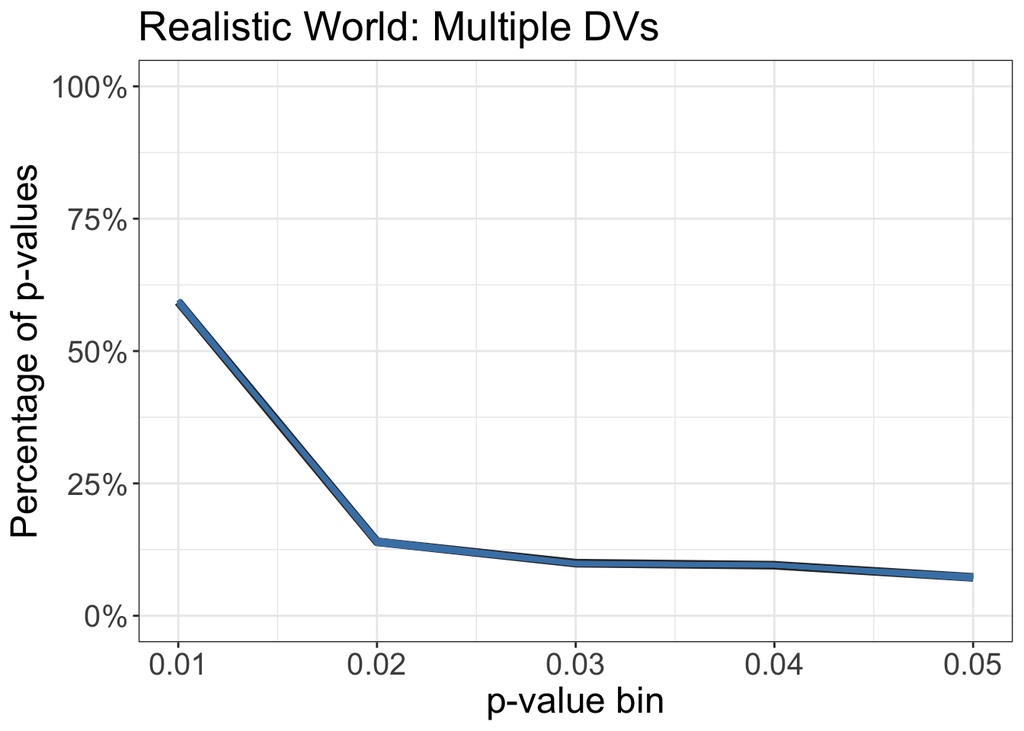

```r
plot_pcurves(simres |> filter(condition == "multDV_realistic"), poriginal = simplify2array(pcurves[2, paste0("p", 1:5)]), n_best = 5, GOF="g2", n_studies = pcurves$nsig[2], tol = 1e-6, title = "Realistic World: Multiple DVs")
```

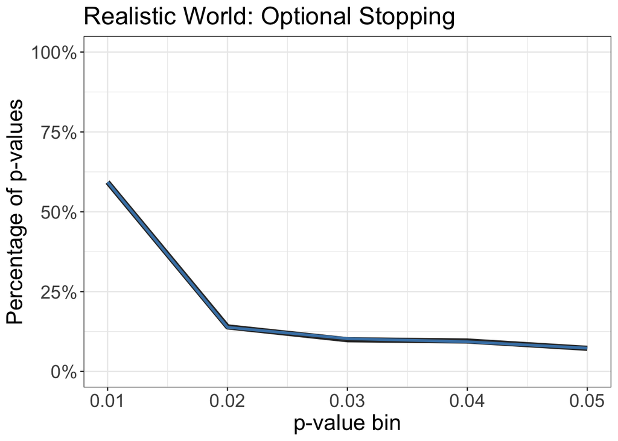

```r
plot_pcurves(simres |> filter(condition == "optStop_realistic"), poriginal = simplify2array(pcurves[2, paste0("p", 1:5)]), n_best = 1, GOF="g2", n_studies = pcurves$nsig[2], tol = 1e-6, title = "Realistic World: Optional Stopping")
```

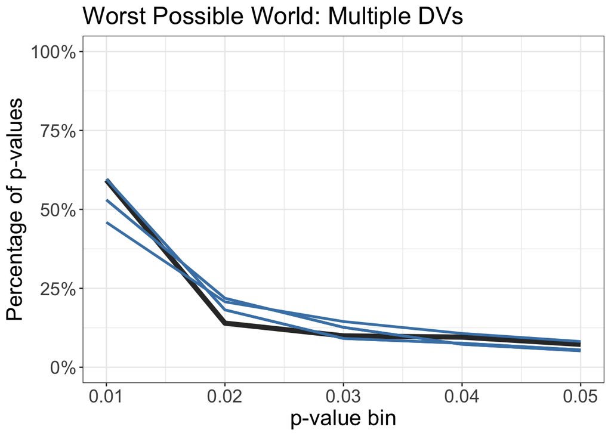

```r
plot_pcurves(simres |> filter(condition == "multDV_worst"), poriginal = simplify2array(pcurves[2, paste0("p", 1:5)]), n_best = 5, GOF="g2", n_studies = pcurves$nsig[2], tol = 1e-6, title = "Worst Possible World: Multiple DVs")
```

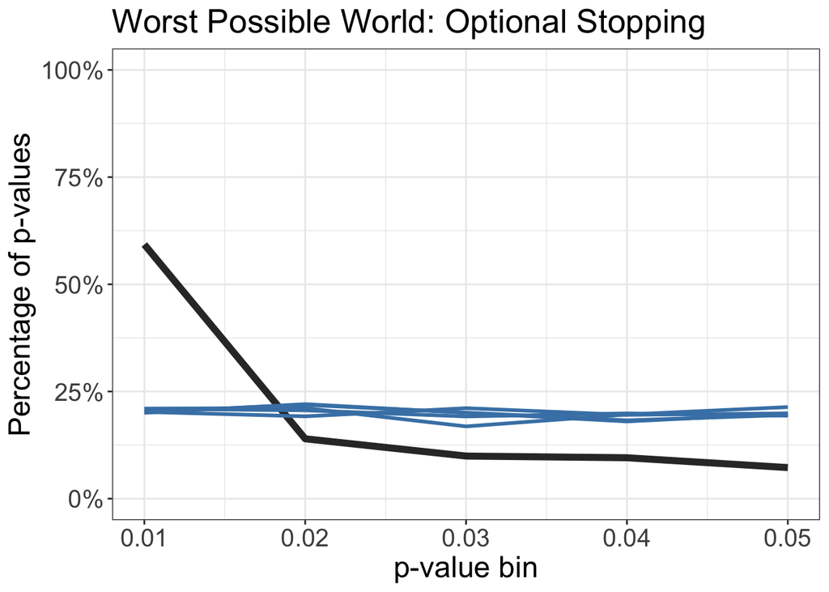

```r
plot_pcurves(simres |> filter(condition == "optStop_worst"), poriginal = simplify2array(pcurves[2, paste0("p", 1:5)]), n_best = 5, GOF="g2", n_studies = pcurves$nsig[2], tol = 1e-6, title = "Worst Possible World: Optional Stopping")
```

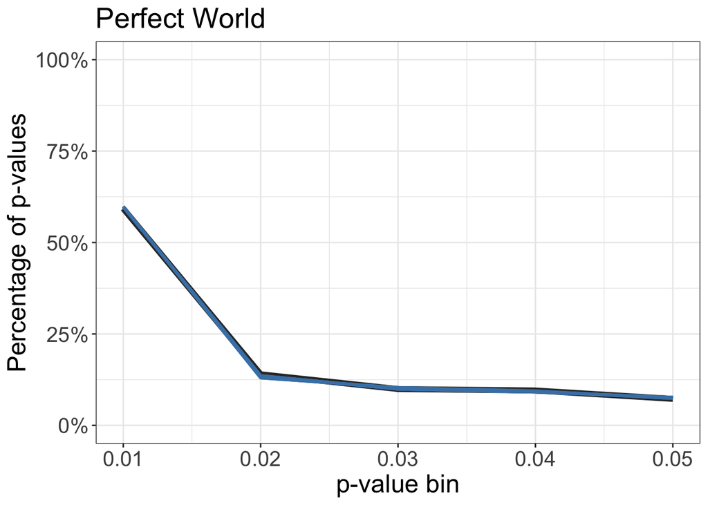

```r
plot_pcurves(simres |> filter(condition == "multDV_perfect"), poriginal = simplify2array(pcurves[2, paste0("p", 1:5)]), n_best = 5, GOF="g2", n_studies = pcurves$nsig[2], tol = 1e-6, title = "Perfect World")
```

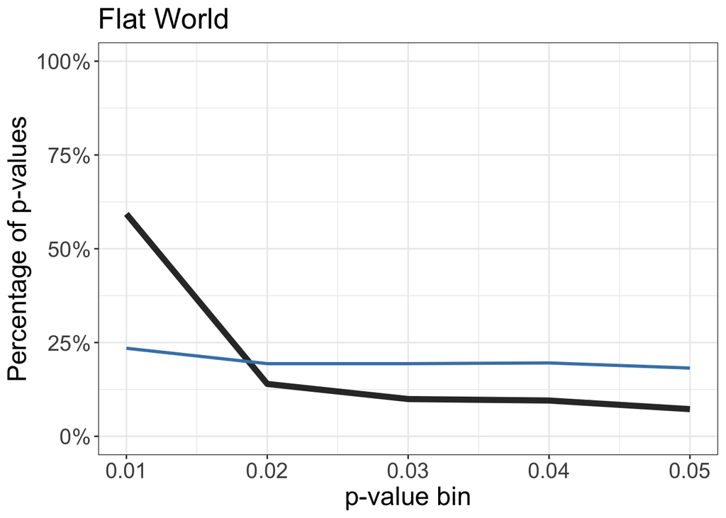

```r
plot_pcurves(simres |> filter(condition == "multDV_H0"), poriginal = simplify2array(pcurves[2, paste0("p", 1:5)]), n_best = 1, GOF="g2", n_studies = pcurves$nsig[2], tol = 1e-6, title = "Flat World")
```

save simres for plotting

```r
save(simres, file = "sim-results/simres_full.RData")
```